# Fijian Earthquakes

Jay Lee

9/7/2017

### Earthquake Detection

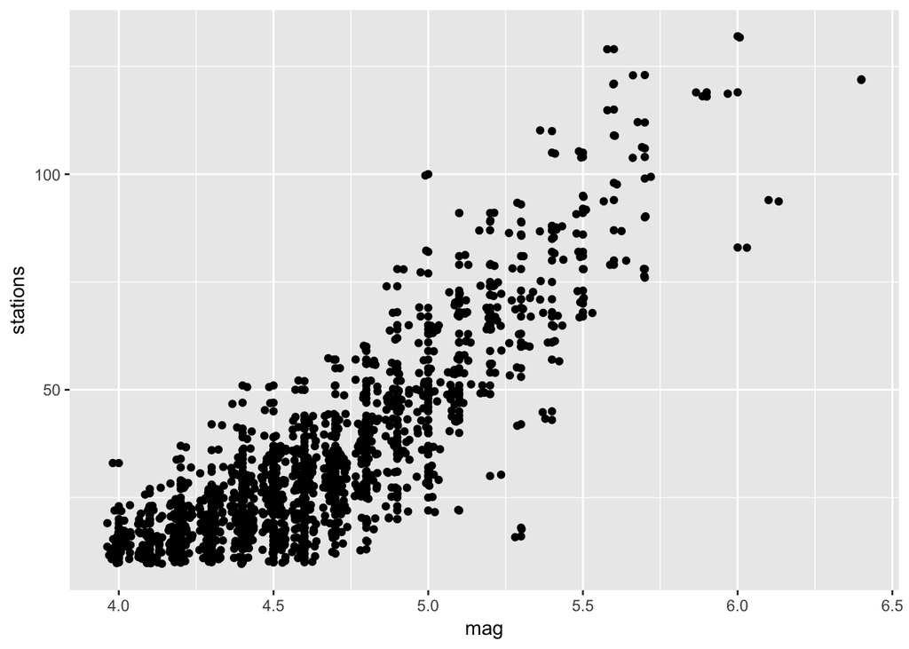

```r
ggplot(quakes, aes(x = mag, y = stations)) +
  geom_point() +
  geom_jitter()
```

The data shows a strong, positive, linear relationship.

2. If there was no relationship between these two values, we would expect the slope of the model to be 0 and the y-intercept to be $\bar{y}$.

```r
m1 <- lm(stations ~ mag, quakes)
summary(m1)
```

```
##
## Call:
## lm(formula = stations ~ mag, data = quakes)
##
## Residuals:
##     Min      1Q  Median      3Q     Max
## -48.871  -7.102  -0.474   6.783  50.244
##
## Coefficients:
##              Estimate Std. Error t value Pr(>|t|)
## (Intercept) -180.4243     4.1899  -43.06   <2e-16 ***
## mag           46.2822     0.9034   51.23   <2e-16 ***
## ---
## Signif. codes:  0 '***' 0.001 '**' 0.01 '*' 0.05 '.' 0.1 ' ' 1
##
## Residual standard error: 11.5 on 998 degrees of freedom
## Multiple R-squared:  0.7245, Adjusted R-squared:  0.7242
## F-statistic:  2625 on 1 and 998 DF,  p-value: < 2.2e-16
```

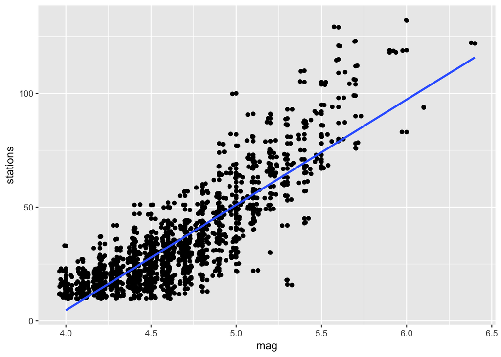

```r
ggplot(quakes, aes(x = mag, y = stations)) +
  geom_point() +
  geom_jitter() +
  geom_smooth(method = "lm", se = F)
```

For every increase of 1 in magnitude, we would expect a quake to be felt by 46.2822 more stations.

```r
x_bar <- mean(quakes$mag)
y_bar <- mean(quakes$stations)
beta_1 <- sum((quakes$mag - x_bar) * (quakes$stations - y_bar)) / sum((quakes$mag - x_bar)^2)
beta_0 <- mean(quakes$stations)-beta_1*mean(quakes$mag)
beta_1
```

```
## [1] 46.28221
```

```r
beta_0
```

```
## [1] -180.4243
```

```r
lower <- 46.2822 - 1.962*.9034
upper <- 46.2822 + 1.962*.9034
lower
```

```
## [1] 44.50973
```

```r
upper
```

```
## [1] 48.05467
```

```r
confint(m1, "mag")
```

```
##        2.5 %   97.5 %
## mag 44.50944 48.05498
```

```r
46.2822*7.0-180.4243
```

```
## [1] 143.5511
```

7. Data description, inference, inference, inference, prediction, prediction

### Simulation

```r
set.seed(385)
sim_data <- sample_n(quakes, 1000, replace = T) %>%
  select(mag)
head(sim_data)
```

```
##     mag
## 813 4.5
## 434 4.8
## 873 4.9
## 997 4.7
## 351 4.6
## 721 4.7
```

```r
f_hat <- function(x) {
  46.2822*x-180.4243
}
sim_data <- sim_data %>%
  mutate(y_hat = f_hat(mag))
head(sim_data)
```

```
##   mag    y_hat
## 1 4.5 27.84560
## 2 4.8 41.73026
## 3 4.9 46.35848
## 4 4.7 37.10204
## 5 4.6 32.47382
## 6 4.7 37.10204
```

```r
set.seed(1738)
RSS <- sum((m1$residuals)^2)
epsilon <- rnorm(1000, mean = 0, sd = sqrt(RSS/(1000-2)))
y <- sim_data$y_hat + epsilon
sim_data <- data.frame(sim_data, epsilon, y) %>%
  mutate(y = ifelse(y < 0, 0, y)) # can't be detected by a negative number of stations
head(sim_data)
```

```
##   mag    y_hat    epsilon        y
## 1 4.5 27.84560  -8.084772 19.76083
## 2 4.8 41.73026  -1.822789 39.90747
## 3 4.9 46.35848 -12.742788 33.61569
## 4 4.7 37.10204   9.622905 46.72495
## 5 4.6 32.47382 -11.670639 20.80318
## 6 4.7 37.10204 -20.156775 16.94527
```

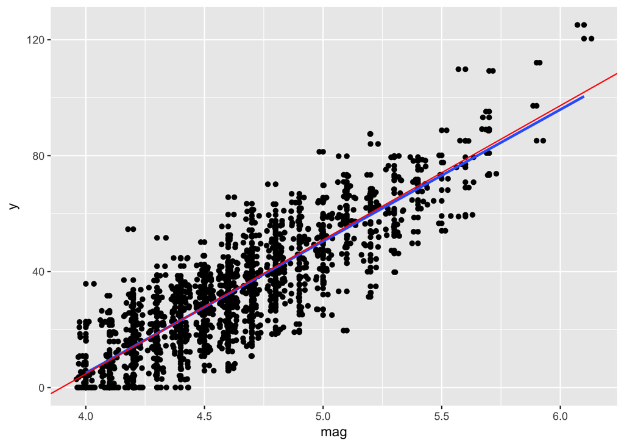

```r
ggplot(sim_data, aes(x = mag, y = y)) +
  geom_point() +
  geom_jitter() +
  geom_smooth(method = "lm", se = F) +
  geom_abline(slope = beta_1, intercept = beta_0, color = "red")
```

The simulated data set appears to match the original data set well. My simulated points (1000 uniform random draws from the original vector of `mag`) don’t appear to have quite as many values for `mag` between 4.0 and 4.5 as the original, so there are fewer points there. This is reflected somewhat in the means of the two `mag` vectors.

```r
mean(quakes$mag)
```

```
## [1] 4.6204
```

```r
mean(sim_data$mag)
```

```
## [1] 4.6316
```

If we form a linear model (below) of the simulated data, we see that both of the simulated model’s parameters are inside the 95% confidence intervals for our original model. The original model is plotted in red above, and the simulated model in blue.

```r
sim <- lm(y~mag, sim_data)
coefficients(sim)
```

```
## (Intercept)         mag
##  -176.78127    45.44735
```

```r
confint(m1, "mag")
```

```
##        2.5 %   97.5 %
## mag 44.50944 48.05498
```

```r
confint(m1, "(Intercept)")
```

```
##                 2.5 %    97.5 %
## (Intercept) -188.6463 -172.2024
```

### Challenge Problem

```r
map <- leaflet(quakes) %>%
  addProviderTiles(providers$OpenMapSurfer.Roads) %>%
  addCircleMarkers(radius = ~mag*10-39, fill = F, weight = 1, opacity = ~stations/200+.1, color = "darkgreen", label = ~as.character(mag))
```

```
## Assuming 'long' and 'lat' are longitude and latitude, respectively
```

```r
map
```

[interactive chart not shown]